# We R Novices

An *R Masterclass Series* Original

Alexander Savi, Amsterdam Center for Learning Analytics

Simone Plak, Amsterdam Center for Learning Analytics

June 23, 2020

[figure not shown]

The *R Novice* badge; learn it before you earn it.

# 1 Welcome

## 1.1 Academic countdown

`5m` Our online version of an academic quarter. We’ll take five minutes for everyone to get in and get settled.

Are you ready?

- This document is open.
- Zoom is open.
- RStudio is open.
- Piazza is open.
- Coffee is ready.
- All done? Familiarize yourself with the document.

## 1.2 Expectations

`5m` What to expect from this course in three dilemma’s.

- Exploit or explore?
- Base R or tidyverse?
- Active or passive?

## 1.3 Learning goals

`5m` R comes with quite a learning curve and there are no shortcuts, only detours. Nevertheless, we aim for a solid introduction. And because we’re researchers, we’ll take the first turn towards data analysis.

- By the end of the masterclass you are able to run rudimentary analyses on readily available data.
- A picture is worth a thousand words, and you will know how to create one.
- Also, you’ll be acquainted with some core concepts. Some of those you’ll use directly, and all will help you as soon as you continue on your own, navigating through R help files, examples, Q&A sites, and so on.
- Continuing on your own does not mean being on your own: we’ll form an R learners community and try to help each other, also after the masterclass.

We have set high goals. It requires a disclaimer.

- We’re not certain we’ll reach all learning goals, but let’s go for it.
- Think of this masterclass as a beta version; there will be bugs, there will be typos. Help us to improve it, we love feedback.
- We are excited and hope you are too!

# 2 R. Getting Around

## 2.1 The R basics

```r
# This script celebrates our first lines of R code

# Create cake object, which is added to environment tab
cake <- 3.14
cake

# Create slices vector
slices <- c(cake / 3, cake / 3, cake / 3)  # a vector object
slices

# Plot slices with pie function
pie(x = slices)  # warning: pie charts are ridiculous, only use them for celebrations

# Let's do it more efficiently
?"rep"
slices <- rep(x = cake / 3, times = 3)
slices

# Let's separate 'ingredients' from 'recipe'
n_participants <- 20
slice <- cake / n_participants
slices <- rep(x = slice, times = n_participants)
pie(x = slices)

# Now, let's give this cake a bit more body
library("plotrix")  # first run install.packages("plotrix") once (we like to leave it out of our script)
plotrix::pie3D(x = slices, explode = .1, main = "There's cake for everyone!")
```

### 2.1.1 Projects

[figure not shown]

RStudio

Going to use R for a new project?

1. Create a project
2. Create a script
3. Comment the script
4. Write the script
5. Save the script

### 2.1.2 Functions

It is absolutely key to understand the idea of a function. Luckily, the idea is straightforward. You put something in a function, and you get out something else.

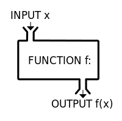

Functions always look like this: `function()`. Between the brackets you enter the input, and possibly some additional arguments for the function to take into account.

**mean()**

Let’s dissect the *mean* function.

```r
some_data <- c(1, 4, 4, 2.356, 25)
mean(x = some_data)
```

```
## [1] 7.2712
```

```r
mean(x = some_data, na.rm = FALSE, trim = 0)  # the mean function uses these default arguments, but you can change them, see below
```

```
## [1] 7.2712
```

Removing missing values (called `NA`’s).

```r
some_data <- c(1, 4, 4, NA, 2.356, 25)
mean(x = some_data)
```

```
## [1] NA
```

```r
mean(x = some_data, na.rm = TRUE)
```

```
## [1] 7.2712
```

Or trim 20% of the observations from each end of the input, before the mean is computed.

```r
mean(x = some_data, trim = .2, na.rm = TRUE)
```

```
## [1] 3.452
```

```r
mean(some_data, .2, TRUE)  # R also interprets the input without explicitly showing the arguments, but only do this when you know what you're doing
```

```
## [1] 3.452
```

**print()**

The print function prints any R object to your console. Conveniently, most of the time you won’t need to explicitly call the print function.

```r
print(x = some_data)  # explicit
```

```
## [1]  1.000  4.000  4.000     NA  2.356 25.000
```

```r
some_data  # implicit
```

```
## [1]  1.000  4.000  4.000     NA  2.356 25.000
```

```r
print(x = some_data, digits = 2)  # explicit with additional arguments
```

```
## [1]  1.0  4.0  4.0   NA  2.4 25.0
```

**length() & round()**

These are two other functions you’ll likely want to use.

```r
length(x = some_data)
```

```
## [1] 6
```

```r
round(x = some_data, digits = 3)
```

```
## [1]  1.000  4.000  4.000     NA  2.356 25.000
```

### 2.1.3 Packages

Functions live in packages. Base R comes with a bunch of pre-installed packages, such as the [base](https://stat.ethz.ch/R-manual/R-devel/library/base/html/00Index.html) package, and you can install additional packages and thus extend the functionality of R. There are currently 15812 available. Crazy! And even crazier, we’ll cover most of them in this masterclass.

No, of course we don’t.

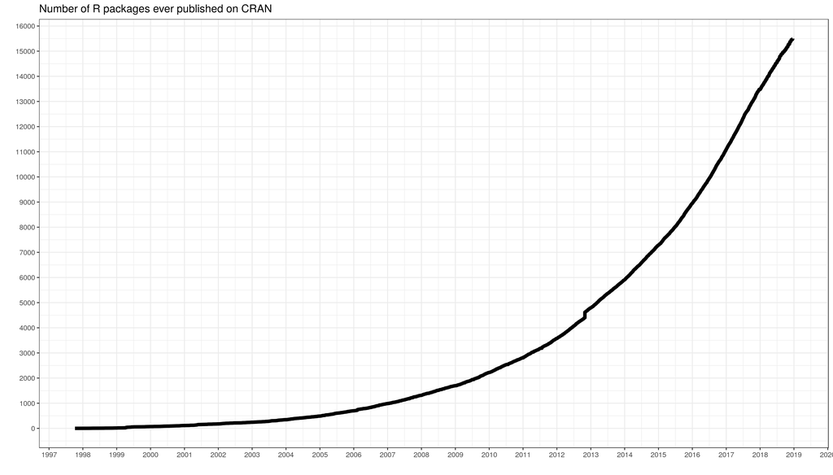

Flattening the curve? Not quite. ([source](https://gist.github.com/daroczig/3cf06d6db4be2bbe3368))

**Installing and loading packages**

Packages must first be installed and can then be loaded. As soon as the package is loaded, all its functions become readily available. In this masterclass we’ll make extensive use of the *tidyverse* package. Although to be honest, it’s not really a package, but rather a [collection of packages](https://www.tidyverse.org/packages/). Installing and loading it will install and load all the packages in the collection.

```r
# Functions that work for all packages
install.packages("tidyverse")  # installs the tidyverse package
library("tidyverse")  # loads the tidyverse package
library(tidyverse)  # also loads the tidyverse package
remove.packages("tidyverse")  # removes the tidyverse package
update.packages()  # updates all packages
installed.packages()  # see which packages are installed
available.packages()  # see which packages are available

# Functions that work for the tidyverse
tidyverse_update()  # updates the tidyverse package
```

Installation of a package generally only needs to be done once for every project you are working on. On the other hand, loading a package generally needs to be done every time you reopen RStudio.

**Masked functions**

Importantly, as anyone can contribute a package, functions from different packages may share the same name. Therefore, when loading a package, R ‘masks’ functions from previously loaded packages if those contain functions with an identical name. To ensure that you’re calling the right function, there are three options:

1. Load packages in a smart order. If you need packages *education* and *fish*, which both have the function *school*, but you only need to use that function from the *education* package: load package *fish* before you load package *education*. You may run `search()` to see in which order R searches packages for functions.
2. Explicitly call the required package. When you use a function, you can tell R directly in which package it must find it. It’s simple: call `package::function()` rather than `function()`.
3. Don’t install additional packages. But only do this if you like life to be utterly boring.

Here, we choose the second option. It’s pedagogically sound and you will never make a mistake. For convenience, we’ll only call the package if it’s from a package that we loaded ourselves.

```r
base::mean()  # the mean function is in the base package, which is pre-installed
mean()  # so we'll just call it like this
tibble::tibble()  # tibble is in the tibble package, so we'll call it like this
```

If you don’t want to understand this in depth (you really don’t), don’t look [here](https://r-pkgs.org/namespace.html), and definitely don’t look [here](https://blog.obeautifulcode.com/R/How-R-Searches-And-Finds-Stuff/).

### 2.1.4 Help (inside R)

**Cheat sheets**

We love cheat sheets. Find them [online](https://rstudio.com/resources/cheatsheets/) or download them directly from your RStudio menu: Help > Cheatsheets.

**Vignettes**

We love vignettes. They are not as complete as help files, but provide an excellent start for getting to know a *package and some of its most important functions*. Unfortunately, many packages don’t come with a vignette.

```r
vignette("dplyr")
```

**Examples**

Some *functions* come with an example. It can be useful to see how a function can be used.

```r
example("mean")
```

**Help**

R has a help function with a convenient shortcut. Use it to get help on *functions and packages*. Be warned, whereas the shortcut is convenient, R’s help pages are generally not.

```r
# Find function or package
apropos("mean")  # find functions with 'mean' in their name
find("mean")  # find package that contains the function 'mean'

# Get help on a function
help("help")  # get help on the help function
?"help"  # shortcut to get help on the help function
?"?"  # shortcut to get help on the shortcut for the help function
?"="  # you can even get help on operators
?help  # also works most of the time, but not always (try ?for)
??"mean"  # find vignettes, code demonstration, help pages

# Get help on a package
help("dplyr")  # r documentation for dplyr
?"dplyr"  # shortcut
help(package = "dplyr")  # help pages for all functions in dplyr
library(help = "dplyr")  # general information on dplyr
```

**SOS**

The *SOS* package provides advanced search functionality.

```r
library("sos")
???"mean"
???"linear regression"  # too many results: use a more restrictive search term
???"repeated measures"(maxPages = 1)
```

**Seized by despair?**

```r
????"mean"
```

### 2.1.5 Assignment

You can *store* and *reuse* pretty much anything in R, by using the assignment operator. You’ll use it a lot. There are various ways you can assign values to an object, but luckily, you only need one.

```r
# Assignment operators
a <- 1  # this is the best, forget the rest
1 -> a
a = 1
assign(x = "a", value = 1)
```

Remember that we do use the `=` operator, but when specifying the arguments in a function.

We can assign all kinds of things to an object, although it only makes sense if we want to store and reuse it.

```r
a <- 1
b <- mean(some_data, na.rm = TRUE)
c <- help("dplyr")  # doesn't make much sense
```

For clarity, use spaces around the assignment operator.

```r
a<-1  # would this mean...
a <- 1  # ...this...
a < -1  # ...or this?
```

Object names can be numbers, even sentences. Think twice before using it.

```r
1 <- 2  # fails, thankfully
`1` <- 2  # backticks do the magic
1 - `1`  # 1 - 2
`This Variable Name is Publication Ready!` <- 2
```

### 2.1.6 Data types and structures

R can handle several different data types and structures. Below, we summarize the types and structures that come with base R, and one that comes with the tidyverse. You’ll recognize the data frame or tibble (a special data frame) as the data structure that you use for data analysis. Nonetheless, it’s good to know that other structures exist too.

Importantly, notice that data types are nested in data structures, and some data structures are nested in other data structures. Vectors hold scalars, data frames and matrices hold vectors, and list can simply hold anything.

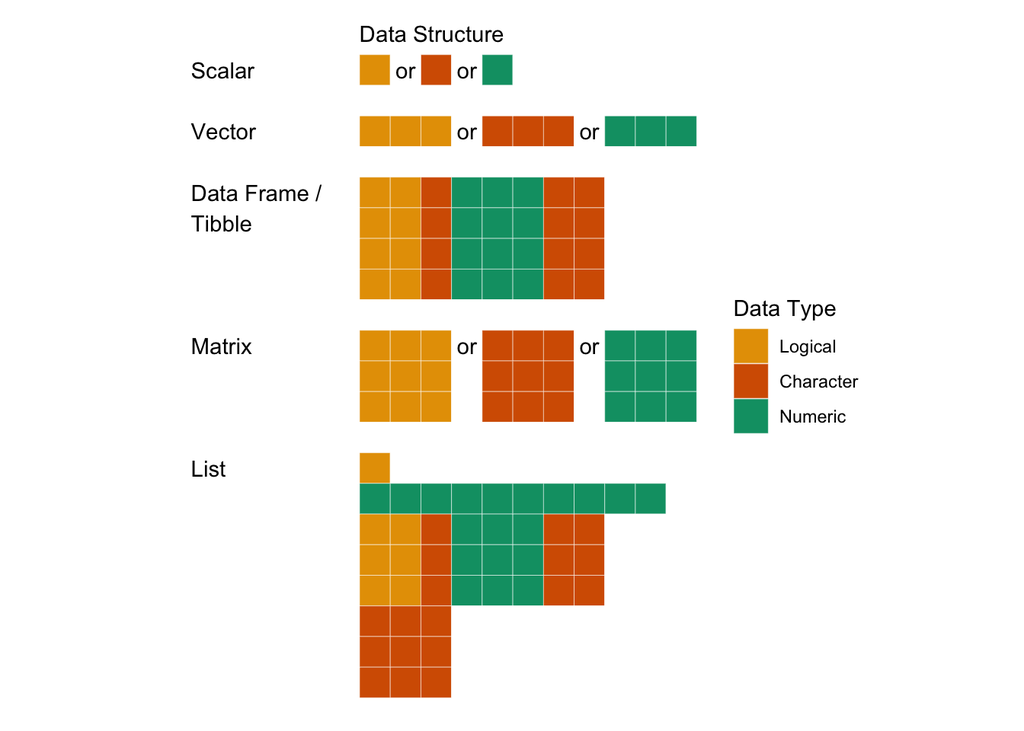

**Scalar**

The data structure that holds a single value, whether numeric, character, or logical, is referred to as a *scalar*.

```r
s_int <- 1L  # numeric (integer)
s_dbl <- 1  # numeric (double)
s_chr <- "R"  # character (some call it a string)
s_lgl <- TRUE  # logical
```

The logical type can be simplified to `T` for `TRUE` and `F` for `FALSE`, but this is not preferred. Also, `TRUE` is stored as `1` and `FALSE` as `0`.

```r
2 * s_lgl
```

```
## [1] 2
```

**Vector**

Use the `c()` function to combine scalars into a vector.

```r
v_dbl <- c(s_dbl, 2, 3, 4)
v_chr <- c("I", "love", s_chr, "!")
print(v_chr)
```

```
## [1] "I"    "love" "R"    "!"
```

Read [this](https://adv-r.hadley.nz/vectors-chap.html#atomic-vectors) if you want to get to the bottom of vectors.

**Factor, one special vector**

The data types you’ll want to use most are numeric and categorical. So where is categorical? It’s here, it’s factor. The `factor` type is a special kind of integer vector that can hold categorical data with different levels. Here, we create a *nominal* factor vector.

```r
v_sex <- c("male", "female", "female")
fct_sex <- factor(x = v_sex, levels = c("female", "male", "other"))
print(fct_sex)
```

```
## [1] male   female female
## Levels: female male other
```

Likewise, here we create an *ordinal* factor vector.

```r
v_lev <- c("student", "professor", "student")
fct_lev <- factor(v_lev, levels = c("student", "phd_candidate", "professor"), order = TRUE)
print(fct_lev)
```

```
## [1] student   professor student
## Levels: student < phd_candidate < professor
```

**Data frame**

Data frames are perfect for data analysis. But not so fast, data frames are base R, we’ll use *tibbles*. You probably don’t want to use `variable_a` and so forth; pick a variable name that makes sense.

```r
df <- data.frame(variable_a = v_dbl, variable_b = v_chr)
print(df)
```

```
##   variable_a variable_b
## 1          1          I
## 2          2       love
## 3          3          R
## 4          4          !
```

**Tibble**

The [tibble](https://tibble.tidyverse.org/) is the tidyverse version of a data frame.

```r
df <- tibble::tibble(variable_a = v_dbl, variable_b = v_chr)
print(df)
```

```
## # A tibble: 4 x 2
##   variable_a variable_b
##        <dbl> <chr>
## 1          1 I
## 2          2 love
## 3          3 R
## 4          4 !
```

**Matrix**

What matrices are good for? Think of correlation matrices or adjacency matrices (used for specifying the links in a network).

```r
m_dbl <- matrix(data = v_dbl, nrow = 2, ncol = 2)
m_dbl_byrow <- matrix(data = v_dbl, nrow = 2, ncol = 2, byrow = TRUE)
print(m_dbl)
```

```
##      [,1] [,2]
## [1,]    1    3
## [2,]    2    4
```

```r
print(m_dbl_byrow)
```

```
##      [,1] [,2]
## [1,]    1    2
## [2,]    3    4
```

A special type of matrix is an *array*. It stacks multiple matrices. Are you likely going to use it? No.

**List**

```r
lst <- list(data_a = s_lgl, data_b = v_chr, data_c = m_dbl, data_d = df, data_e = list(v_dbl))
print(lst)
```

```
## $data_a
## [1] TRUE
##
## $data_b
## [1] "I"    "love" "R"    "!"
##
## $data_c
##      [,1] [,2]
## [1,]    1    3
## [2,]    2    4
##
## $data_d
## # A tibble: 4 x 2
##   variable_a variable_b
##        <dbl> <chr>
## 1          1 I
## 2          2 love
## 3          3 R
## 4          4 !
##
## $data_e
## $data_e[[1]]
## [1] 1 2 3 4
```

Indeed, if you want to get funky, you can even nest a list in a list.

### 2.1.7 Coercion

Conveniently, we can force the one data type into the other if we need to. This is called coercion.

```r
as.integer(c("3.14", "b"))
as.double(c("-1", "b"))
as.character(c(-1, NA))
```

[output not shown]

```
## [1] "-1" NA
```

```r
as.logical(c(0, 1, 2))
```

```
## [1] FALSE  TRUE  TRUE
```

```r
as.factor(c("R", "JASP", "jamovi"))
```

```
## [1] R      JASP   jamovi
## Levels: jamovi JASP R
```

Coercion is performed automatically when we try to create a vector with different data types. Values are then coerced to the value with the highest rank, where logical < integer < double < character. This is illustrated below.

```r
c(TRUE, 33L, 3.14, "R")
```

```
## [1] "TRUE" "33"   "3.14" "R"
```

```r
c(TRUE, 33L, 3.14)
```

```
## [1]  1.00 33.00  3.14
```

```r
c(TRUE, 33L)
```

```
## [1]  1 33
```

### 2.1.8 Operators

There are many operators in R. Here’s a few that may come in handy.

```r
# Arithmetic operators
1 + 2
```

```
## [1] 3
```

```r
1 - 2
```

```
## [1] -1
```

```r
1 * 2
```

```
## [1] 2
```

```r
1 / 2
```

```
## [1] 0.5
```

```r
1^2
```

```
## [1] 1
```

```r
sqrt(1)  # oops, a function, the square root
```

```
## [1] 1
```

```r
# Relational operators
1 == 2
```

```
## [1] FALSE
```

```r
1 != 2
```

```
## [1] TRUE
```

```r
1 < 2
```

```
## [1] TRUE
```

```r
1 > 2
```

```
## [1] FALSE
```

```r
1 <= 2
```

```
## [1] TRUE
```

```r
1 >= 2
```

```
## [1] FALSE
```

```r
# Logical operators
!TRUE
```

```
## [1] FALSE
```

```r
TRUE & FALSE
```

```
## [1] FALSE
```

```r
TRUE | FALSE
```

```
## [1] TRUE
```

### 2.1.9 Into the void

> “Youth always tries to fill the void, an old man learns to live with it.” — Mark Z. Danielewski

In data analysis, you’ll be mostly concerned with `NA`, used to indicate missing values. `NA` is used regardless of the type of data (character, logical, numeric). However, there’s more emptiness in R than just missing values.

```r
NA  # NA stands for Not Available; indicates a missing element
```

```
## [1] NA
```

```r
0 / 0  # NaN stands for Not a Number; indicates an incorrect computation
```

```
## [1] NaN
```

```r
1 / 0  # Inf stands for Infinite; indicates an infinite element
```

```
## [1] Inf
```

```r
c()  # NULL; indicates the absence of a vector or an empty vector
## NULL
```

You don’t need meditation to find the void:

```r
void <- c(NA, NaN, Inf, NULL)
print(void)  # NULL pertains to vectors and is thus (silently) removed
```

```
## [1]  NA NaN Inf
```

```r
is.na(void)  # both NA and NaN are considered missing elements
```

```
## [1]  TRUE  TRUE FALSE
```

```r
is.nan(void)
```

```
## [1] FALSE  TRUE FALSE
```

```r
is.infinite(void)
```

```
## [1] FALSE FALSE  TRUE
```

```r
is.null(void)  # the vector void is not empty
```

```
## [1] FALSE
```

Pro tip: if you don’t like missing values (who does), follow the *We R Programmers* masterclass and learn about simulations.

## 2.2 Exercises

### Tibble

*Doing data analysis in R, you’ll work with tibbles all the time. This is an exercise you should focus on.*

**Instruction**

Create a tibble with five variables that each contain five observations. One logical variable, one double (numeric) variable, one character variable, one nominal categorical variable, and one ordinal categorical variable.

For each type, think of a variable that matches the type (e.g., sex as a nominal categorical variable), and give it a name that clearly communicates it.

Let’s make it look like real data and make sure each variable contains a missing value.

**Tips**

- Tibbles contain vectors, vectors contain scalars. Check scalars if you want to understand variable types. You’ll find all of it in the *data types and structures* section.
- Categorical variables are represented by *factors*. Find them in the *data types and structures* section.
- Missing values are indicated with `NA`. Check the *into the void* section.

### Fix it?

*These exercises can be hard, but are important if you want to learn R. It doesn’t matter if you can’t do them during the masterclass, but make sure to work on them afterwards.*

**Instruction**

Check and run the examples below.

- Can you see what’s going on?
- Do you think it does what it’s supposed to do? Why or why not? ‘It depends’ can also be answer.
- If you think it doesn’t do what it’s supposed to do, can you fix it?
- Stuck on one? Don’t waste all your time on it and continue.

```r
# 1
s <- "Is R case-sensitive?"
print(S)

# 2
r <- n <- o <- v <- i <- c <- e <- 1

# 3
r < -1

# 4
v <- c(1, 2, 3, NA)
mean(v)

# 5
v <- c(1, 2, 3, "NA")
mean(v)

# 6
v <- c("a", "b", "c", "d")
mean(v)

# 7
v <- c(TRUE, FALSE, TRUE, FALSE)
mean(v)

# 8
mean <- c(1, 2, 3, 4)
mean(mean)

# 9
v <- c("1", "2", "3", "NA")
as.numeric(v)

# 10
TRUE != FALSE & (TRUE == !TRUE | TRUE >= FALSE)

# 11
NA == NA

# 12
?"?"

# 13
????"mean"
```

**Tips**

Work through the resources in the previous sections to find the answers.

### Solutions

You wish it would be easy like that.

Thankfully, you’re not the only one learning R. Ask and help each other. Use Piazza. Consult us. R is not easy, but we’re 100% sure you’ll grasp it when you put effort in it!

## 2.3 Discussion

## 2.4 Break

[figure not shown]

xkcd.com

# 3 Tidyverse. From Data to Knowledge

## 3.1 A tidy touch on data analysis

Again, let’s first go through a fully working script, and then discuss the different parts.

### 3.1.1 Data set

The data used in this fully working script is from a [paper](https://journals.sagepub.com/doi/full/10.1177/0956797611417632) published in 2011 that aimed to show how flexibility in data collection, analysis, and reporting can dramatically increase false-positive rates (Simmons, Nelson, & Simonsohn, 2011). They demonstrate how flexibility on these different aspects can result in statistically significant evidence for a false hypothesis. The data used here, is the data from their Study 1.

```r
# loading necessary collections and packages
library("tidyverse")
library("tidymodels")
library("magrittr")

# read in data & take a quick look
Study_1 <- readr::read_delim("FalsePositive_Data_in_/Study 1 .txt", delim = "\t", escape_double = FALSE, trim_ws = TRUE)
Study_1
View(Study_1)

# mean age in years per group
Study_1 %>%
  dplyr::group_by(cond) %>%
  dplyr::summarize(mean = mean(aged365))

# mean of all numeric variables
Study_1 %>%
  dplyr::group_by(cond) %>%
  dplyr::summarize(across(where(is.numeric), mean))

# descriptive statistics: age in years per group
Study_1 %>%
  dplyr::group_by(cond) %>%
  dplyr::summarize(across(c(aged365), list(mean = mean, sd = sd, min = min, max = max)), n = n())

# boxplot
Study_1 %>%
  ggplot2::ggplot(aes(x = cond, y = aged365, fill = cond)) +
  geom_boxplot()

# ANOVA (group differences in age)
res_aov <- stats::aov(aged365 ~ cond, data = Study_1) # fit the model
broom::tidy(res_aov) # model results
broom::glance(res_aov) # additional model results
res_pairw <- stats::TukeyHSD(res_aov) # pairwise comparisons
broom::tidy(res_pairw) # pairwise comparison results

# Or: Linear regression with 2 dummies to indicate group assignment
res_lm <- stats::lm(aged365 ~ potato + when64, data = Study_1)
broom::glance(res_lm) # whole model results
broom::tidy(res_lm) # coefficients
```

### 3.1.2 Tidyverse

[Tidyverse](https://www.tidyverse.org/packages/) is a collection of R packages designed for data science.

The core tidyverse packages we use in this workshop:

- *readr* – reading in data (see subsection: Reading data)
- *tibble* – the tidyverse version of a data frame (see subsection: Data types and structures)
- *dplyr* – data manipulation (see subsection: The dplyr package)
- *ggplot2* – visualization (see subsection: Plotting)

### 3.1.3 Reading data

*readr* package for reading in text files (e.g., .txt, .csv files):

```r
readr::read_csv("file.csv") # comma delimited files
readr::read_csv2("file2.csv") # semi-colon delimited files
read_delim("file.txt", delim = "|") # files with any delimiter (e.g. |)
```

You could also use the Import Dataset dropdown menu under the environment tab. Choose the From Text (readr) option.

Reading other files

- *haven* – SPSS, Stata, and SAS files
- *readxl* – Excel files (.xls and .xlsx)

```r
haven::read_sav("file.sav") # SPSS
haven::read_dta("file.dta") # Stata
haven::read_sas("file.sas7bdat") # SAS
readxl::read_excel("file.xlsx") # Excel
```

### 3.1.4 Take a look at your data

We will show some examples using the built-in data set in R called *iris*.

```r
?iris # explanation of this data
data("iris") # load data
iris <- as_tibble(iris) # make it a tibble
```

There are various ways to take a look at your data, here are a couple:

```r
iris # shows the first rows of the data
View(iris) # opens spreadsheet-style data viewer
dplyr::sample_n(iris, 8) # random sample of 8 participants
colnames(iris) # variable names
```

### 3.1.5 Useful operators

**Tilde operator**

`~` – The tilde operator separates the left- and right-hand sides in a model formula. For instance, a regression model with two independent variables and no interaction effect can be specified by: `y ~ x + z`. See the subsection Statistical tests & Tidymodels below for examples of how to use a model formula in a statistical analysis.

**As Is function**

`I()` – This function is used to inhibit the interpretation of operators such as `+`, `-`, `*` and `^` as formula operators. For example, when you want x to the power 2 in your model formula: `y ~ I(x^2) + z`.

**Pipe operator**

`%>%` – With this operator you can pipe a value forward into a function. So instead of `mean(x)`, you could use `x %>% mean()`. This can improve the readability and maintainability of your code and decrease development time.

```r
x1 <- c(9, 3, 5, 7, 1) # random vector
x2 <- c(1, 7, 5, 9, 2) # random vector
sqrt(sum((x1 - x2)^2)) # nest function within each other
```

```
## [1] 9.219544
```

```r
(x1 - x2) %>% `^`(2) %>% sum() %>% sqrt() # use the pipe operator
```

```
## [1] 9.219544
```

### 3.1.6 The dplyr package

The *dplyr* package in the Tidyverse collection has some useful data manipulation tools for (among other things) computing descriptive statistics.

Some helpful functions in this package you will likely use:

- [select](https://dplyr.tidyverse.org/reference/select.html) – to select columns by name
- [filter](https://dplyr.tidyverse.org/reference/filter.html) – to keep rows matching a certain criteria (create a subset of the data)
- [group_by](https://dplyr.tidyverse.org/reference/group_by.html) – allows you to perform any operation
- [summarise](https://dplyr.tidyverse.org/reference/summarise.html) – to reduce variables to values

**select** examples:

```r
# select one variable by name
iris %>%
  dplyr::select(Species)

# select the variables whose names start with Petal
iris %>%
  dplyr::select(starts_with("Petal"))

# select the numerical variables
iris %>%
  dplyr::select(where(is.numeric))

# select all variables from Petal.Length to Species
iris %>%
  dplyr::select(Petal.Length:Species)

# select the numerical variables that contain an S
iris %>%
  dplyr::select(where(is.numeric) & contains("S"))
```

**filter** examples:

```r
# keep only rows where the sepal length is smaller than 6
iris %>%
  dplyr::filter(Sepal.Length < 6)

# keep only rows of the versicolor species
iris %>%
  dplyr::filter(Species == "versicolor")

# keep only rows of the setosa species where the petal length is larger than 1.5
iris %>%
  dplyr::filter(Species == "setosa" & Petal.Length > 1.5)

# keep only rows where the sepal width is bigger than the mean
iris %>%
  dplyr::filter(Sepal.Width > mean(Sepal.Width))
```

**summarize** examples (the last one including **group_by**):

```r
# the mean of sepal length and number of observations
iris %>%
  dplyr::summarize(mean = mean(Sepal.Length), n = n())
```

```
## # A tibble: 1 x 2
##    mean     n
##   <dbl> <int>
## 1  5.84   150
```

```r
# the mean of all numeric variables
iris %>%
  dplyr::summarize(across(where(is.numeric), mean))
```

```
## # A tibble: 1 x 4
##   Sepal.Length Sepal.Width Petal.Length Petal.Width
##          <dbl>       <dbl>        <dbl>       <dbl>
## 1         5.84        3.06         3.76        1.20
```

```r
# now grouped by type of species
iris %>%
  dplyr::group_by(Species) %>%
  dplyr::summarize(across(where(is.numeric), mean))
## `summarise()` ungrouping output (override with `.groups` argument)
## # A tibble: 3 x 5
##   Species    Sepal.Length Sepal.Width Petal.Length Petal.Width
##   <fct>             <dbl>       <dbl>        <dbl>       <dbl>
## 1 setosa             5.01        3.43         1.46       0.246
## 2 versicolor         5.94        2.77         4.26       1.33
## 3 virginica          6.59        2.97         5.55       2.03
```

### 3.1.7 Descriptive statistics functions

You have already seen the **mean** function a couple times. Here are some additional descriptive statistics functions that you can use inside the **summarize** function from the *dplyr* package.

```r
iris %>%
  dplyr::summarize(median = median(Sepal.Length)) # the median

iris %>%
  dplyr::summarize(min = min(Sepal.Length)) # the minimum

iris %>%
  dplyr::summarize(max = max(Sepal.Length)) # the maximum

iris %>%
  dplyr::summarize(sd = sd(Sepal.Length)) # the standard deviation

iris %>%
  dplyr::summarize(sum = sum(Sepal.Length)) # the sum
```

### 3.1.8 Statistical tests & Tidymodels

Here we provide a few examples of how to run some basic statistical tests. We will provide examples for how to fit:

- A one-way ANOVA
- A regression analysis (simple and multiple)
- A t-test (independent and paired)

To obtain the results of these fitted models, we need the package `broom` from *tidymodels*.

**tidymodels**

[Tidymodels](https://www.tidymodels.org) is another collection of packages (just like tidyverse) designed for modeling and machine learning using tidyverse principles. The only package we will discuss in this workshop is `broom`, as it provides nice output for various statistical tests.

The [**broom**](https://broom.tidymodels.org) package summarizes key information about all kind of fitted statistical models into a tidy tibble.

- *tidy* – summarizes info on the model components, like regression coefficients.
- *glance* – reports information about the entire model, like the R squared and model fit measures.
- *augment* – adds information such as the fitted values and the residuals to the columns of the data.

Run `vignette("available-methods")` to see the statistical functions/packages that currently work with broom. Below we illustrate how you can use these functions to obtain ANOVA, regression, and t-test results.

**one-way ANOVA**

We conduct a one-way ANOVA to test whether the three plant species differ in sepal length. Followed by pairwise comparisons.

```r
# one-way ANOVA
res_aov <- stats::aov(Sepal.Length ~ Species, data = iris)  # omnibus test
broom::tidy(res_aov)  # model results
```

```
## # A tibble: 2 x 6
##   term         df sumsq meansq statistic   p.value
##   <chr>     <dbl> <dbl>  <dbl>     <dbl>     <dbl>
## 1 Species       2  63.2 31.6        119.  1.67e-31
## 2 Residuals   147  39.0  0.265       NA  NA
```

```r
broom::glance(res_aov)  # additional model results
```

```
## # A tibble: 1 x 11
##   r.squared adj.r.squared sigma statistic  p.value    df logLik   AIC   BIC
##       <dbl>         <dbl> <dbl>     <dbl>    <dbl> <int>  <dbl> <dbl> <dbl>
## 1     0.619         0.614 0.515      119. 1.67e-31     3  -112.  231.  243.
## # … with 2 more variables: deviance <dbl>, df.residual <int>
```

```r
res_pairw <- stats::TukeyHSD(res_aov)  # pairwise comparisons
broom::tidy(res_pairw)  # results pairwise comparisons
```

```
## # A tibble: 3 x 6
##   term    comparison           estimate conf.low conf.high adj.p.value
##   <chr>   <chr>                   <dbl>    <dbl>     <dbl>       <dbl>
## 1 Species versicolor-setosa       0.93     0.686     1.17     3.39e-14
## 2 Species virginica-setosa        1.58     1.34      1.83     3.00e-15
## 3 Species virginica-versicolor    0.652    0.408     0.896    8.29e- 9
```

```r
broom::augment(res_aov)  # i.a. fitted values and residuals
```

```
## # A tibble: 150 x 9
##    Sepal.Length Species .fitted .se.fit   .resid   .hat .sigma .cooksd
##           <dbl> <fct>     <dbl>   <dbl>    <dbl>  <dbl>  <dbl>   <dbl>
##  1          5.1 setosa     5.01  0.0728  0.094   0.0200  0.516 2.31e-4
##  2          4.9 setosa     5.01  0.0728 -0.106   0.02    0.516 2.94e-4
##  3          4.7 setosa     5.01  0.0728 -0.306   0.02    0.516 2.45e-3
##  4          4.6 setosa     5.01  0.0728 -0.406   0.02    0.515 4.32e-3
##  5          5   setosa     5.01  0.0728 -0.00600 0.02    0.517 9.43e-7
##  6          5.4 setosa     5.01  0.0728  0.394   0.02    0.515 4.07e-3
##  7          4.6 setosa     5.01  0.0728 -0.406   0.02    0.515 4.32e-3
##  8          5   setosa     5.01  0.0728 -0.00600 0.02    0.517 9.43e-7
##  9          4.4 setosa     5.01  0.0728 -0.606   0.02    0.514 9.62e-3
## 10          4.9 setosa     5.01  0.0728 -0.106   0.02    0.516 2.94e-4
## # … with 140 more rows, and 1 more variable: .std.resid <dbl>
```

**regression**

Instead of an ANOVA, we can also perform a regression analysis to test whether the species versicolor differs from the species setosa, and whether the species virginica differ from setosa in sepal length. Thus, the setosa group is the reference group. You can only put a categorical variable into `lm()` when it is a factor (otherwise, you’d have to create dummy variables or change your character vector to a factor).

```r
# Regression (with species as factor!)
res_lm1 <- stats::lm(Sepal.Length ~ Species, data = iris)
broom::glance(res_lm1)
```

```
## # A tibble: 1 x 11
##   r.squared adj.r.squared sigma statistic  p.value    df logLik   AIC   BIC
##       <dbl>         <dbl> <dbl>     <dbl>    <dbl> <int>  <dbl> <dbl> <dbl>
## 1     0.619         0.614 0.515      119. 1.67e-31     3  -112.  231.  243.
## # … with 2 more variables: deviance <dbl>, df.residual <int>
```

```r
broom::tidy(res_lm1)
```

```
## # A tibble: 3 x 5
##   term              estimate std.error statistic   p.value
##   <chr>                <dbl>     <dbl>     <dbl>     <dbl>
## 1 (Intercept)           5.01    0.0728     68.8  1.13e-113
## 2 Speciesversicolor     0.93    0.103       9.03 8.77e- 16
## 3 Speciesvirginica      1.58    0.103      15.4  2.21e- 32
```

```r
broom::augment(res_lm1) # i.a. fitted values and residuals
```

```
## # A tibble: 150 x 9
##    Sepal.Length Species .fitted .se.fit   .resid   .hat .sigma .cooksd
##           <dbl> <fct>     <dbl>   <dbl>    <dbl>  <dbl>  <dbl>   <dbl>
##  1          5.1 setosa     5.01  0.0728  0.094   0.0200  0.516 2.31e-4
##  2          4.9 setosa     5.01  0.0728 -0.106   0.02    0.516 2.94e-4
##  3          4.7 setosa     5.01  0.0728 -0.306   0.02    0.516 2.45e-3
##  4          4.6 setosa     5.01  0.0728 -0.406   0.02    0.515 4.32e-3
##  5          5   setosa     5.01  0.0728 -0.00600 0.02    0.517 9.43e-7
##  6          5.4 setosa     5.01  0.0728  0.394   0.02    0.515 4.07e-3
##  7          4.6 setosa     5.01  0.0728 -0.406   0.02    0.515 4.32e-3
##  8          5   setosa     5.01  0.0728 -0.00600 0.02    0.517 9.43e-7
##  9          4.4 setosa     5.01  0.0728 -0.606   0.02    0.514 9.62e-3
## 10          4.9 setosa     5.01  0.0728 -0.106   0.02    0.516 2.94e-4
## # … with 140 more rows, and 1 more variable: .std.resid <dbl>
```

Next, we show an example of:

- A simple regression with Sepal.Length as the dependent variable and Sepal.Width as the independent variable.
- A multiple regression with Sepal.Length as the dependent variable and all other variables as independent variables. (e.g. when you want to predict sepal length with all other variables in your data set)
- A multiple regression including an interaction term, where Sepal.Length is the dependent variable, and Petal.Length and Petal.Width are the independent variables and the interaction between these two variables is included.

```r
# simple regression
res_lm2 <- stats::lm(Sepal.Length ~ Sepal.Width, data = iris) # fit the model
broom::glance(res_lm2) # whole model results
```

```
## # A tibble: 1 x 11
##   r.squared adj.r.squared sigma statistic p.value    df logLik   AIC   BIC
##       <dbl>         <dbl> <dbl>     <dbl>   <dbl> <int>  <dbl> <dbl> <dbl>
## 1    0.0138       0.00716 0.825      2.07   0.152     2  -183.  372.  381.
## # … with 2 more variables: deviance <dbl>, df.residual <int>
```

```r
broom::tidy(res_lm2) # coefficients
```

```
## # A tibble: 2 x 5
##   term        estimate std.error statistic  p.value
##   <chr>          <dbl>     <dbl>     <dbl>    <dbl>
## 1 (Intercept)    6.53      0.479     13.6  6.47e-28
## 2 Sepal.Width   -0.223     0.155     -1.44 1.52e- 1
```

```r
broom::augment(res_lm2) # i.a. fitted values and residuals
```

```
## # A tibble: 150 x 9
##    Sepal.Length Sepal.Width .fitted .se.fit .resid    .hat .sigma .cooksd
##           <dbl>       <dbl>   <dbl>   <dbl>  <dbl>   <dbl>  <dbl>   <dbl>
##  1          5.1         3.5    5.74  0.0962 -0.644 0.0136   0.826 0.00426
##  2          4.9         3      5.86  0.0680 -0.956 0.00678  0.824 0.00462
##  3          4.7         3.2    5.81  0.0709 -1.11  0.00739  0.823 0.00680
##  4          4.6         3.1    5.83  0.0677 -1.23  0.00673  0.822 0.00763
##  5          5           3.6    5.72  0.108  -0.722 0.0171   0.826 0.00677
##  6          5.4         3.9    5.66  0.147  -0.255 0.0318   0.828 0.00162
##  7          4.6         3.4    5.77  0.0858 -1.17  0.0108   0.822 0.0111
##  8          5           3.4    5.77  0.0858 -0.767 0.0108   0.825 0.00477
##  9          4.4         2.9    5.88  0.0717 -1.48  0.00754  0.819 0.0123
## 10          4.9         3.1    5.83  0.0677 -0.934 0.00673  0.824 0.00437
## # … with 140 more rows, and 1 more variable: .std.resid <dbl>
```

```r
# multiple regression
res_lm3 <- stats::lm(Sepal.Length ~ Sepal.Width + Petal.Length + Petal.Width + Species, data = iris) # fit the model
broom::glance(res_lm3) # whole model results
```

```
## # A tibble: 1 x 11
##   r.squared adj.r.squared sigma statistic  p.value    df logLik   AIC   BIC
##       <dbl>         <dbl> <dbl>     <dbl>    <dbl> <int>  <dbl> <dbl> <dbl>
## 1     0.867         0.863 0.307      188. 2.67e-61     6  -32.6  79.1  100.
## # … with 2 more variables: deviance <dbl>, df.residual <int>
```

```r
broom::tidy(res_lm3) # coefficients
```

```
## # A tibble: 6 x 5
##   term              estimate std.error statistic  p.value
##   <chr>                <dbl>     <dbl>     <dbl>    <dbl>
## 1 (Intercept)          2.17     0.280       7.76 1.43e-12
## 2 Sepal.Width          0.496    0.0861      5.76 4.87e- 8
## 3 Petal.Length         0.829    0.0685     12.1  1.07e-23
## 4 Petal.Width         -0.315    0.151      -2.08 3.89e- 2
## 5 Speciesversicolor   -0.724    0.240      -3.01 3.06e- 3
## 6 Speciesvirginica    -1.02     0.334      -3.07 2.58e- 3
```

```r
broom::augment(res_lm3) # i.a. fitted values and residuals
```

```
## # A tibble: 150 x 12
##    Sepal.Length Sepal.Width Petal.Length Petal.Width Species .fitted .se.fit
##           <dbl>       <dbl>        <dbl>       <dbl> <fct>     <dbl>   <dbl>
##  1          5.1         3.5          1.4         0.2 setosa     5.00  0.0448
##  2          4.9         3            1.4         0.2 setosa     4.76  0.0551
##  3          4.7         3.2          1.3         0.2 setosa     4.77  0.0469
##  4          4.6         3.1          1.5         0.2 setosa     4.89  0.0514
##  5          5           3.6          1.4         0.2 setosa     5.05  0.0474
##  6          5.4         3.9          1.7         0.4 setosa     5.39  0.0559
##  7          4.6         3.4          1.4         0.3 setosa     4.92  0.0448
##  8          5           3.4          1.5         0.2 setosa     5.04  0.0441
##  9          4.4         2.9          1.4         0.2 setosa     4.71  0.0608
## 10          4.9         3.1          1.5         0.1 setosa     4.92  0.0529
## # … with 140 more rows, and 5 more variables: .resid <dbl>, .hat <dbl>,
## #   .sigma <dbl>, .cooksd <dbl>, .std.resid <dbl>
```

```r
# multiple regression with interaction term
res_lm4 <- stats::lm(Sepal.Length ~ Petal.Length + Petal.Width + Petal.Length:Petal.Width, data = iris) # fit the model
broom::glance(res_lm4) # whole model results
```

```
## # A tibble: 1 x 11
##   r.squared adj.r.squared sigma statistic  p.value    df logLik   AIC   BIC
##       <dbl>         <dbl> <dbl>     <dbl>    <dbl> <int>  <dbl> <dbl> <dbl>
## 1     0.808         0.804 0.367      205. 4.51e-52     4  -60.3  131.  146.
## # … with 2 more variables: deviance <dbl>, df.residual <int>
```

```r
broom::tidy(res_lm4) # coefficients
```

```
## # A tibble: 4 x 5
##   term                     estimate std.error statistic  p.value
##   <chr>                       <dbl>     <dbl>     <dbl>    <dbl>
## 1 (Intercept)                 4.58     0.112      40.9  7.79e-82
## 2 Petal.Length                0.442    0.0655      6.74 3.38e-10
## 3 Petal.Width                -1.24     0.219      -5.65 8.16e- 8
## 4 Petal.Length:Petal.Width    0.189    0.0336      5.62 9.50e- 8
```

```r
broom::augment(res_lm4) # i.a. fitted values and residuals
```

```
## # A tibble: 150 x 10
##    Sepal.Length Petal.Length Petal.Width .fitted .se.fit   .resid   .hat .sigma
##           <dbl>        <dbl>       <dbl>   <dbl>   <dbl>    <dbl>  <dbl>  <dbl>
##  1          5.1          1.4         0.2    5.00  0.0542  9.95e-2 0.0218  0.368
##  2          4.9          1.4         0.2    5.00  0.0542 -1.00e-1 0.0218  0.368
##  3          4.7          1.3         0.2    4.95  0.0559 -2.53e-1 0.0232  0.367
##  4          4.6          1.5         0.2    5.05  0.0532 -4.48e-1 0.0210  0.366
##  5          5            1.4         0.2    5.00  0.0542 -4.59e-4 0.0218  0.368
##  6          5.4          1.7         0.4    4.96  0.0470  4.39e-1 0.0164  0.366
##  7          4.6          1.4         0.3    4.90  0.0522 -3.03e-1 0.0203  0.367
##  8          5            1.5         0.2    5.05  0.0532 -4.84e-2 0.0210  0.368
##  9          4.4          1.4         0.2    5.00  0.0542 -6.00e-1 0.0218  0.365
## 10          4.9          1.5         0.1    5.14  0.0622 -2.44e-1 0.0288  0.367
## # … with 140 more rows, and 2 more variables: .cooksd <dbl>, .std.resid <dbl>
```

**t-test**

In order to illustrate t-tests we need data of two groups (not three). Hence, we will use the built-in data `sleep`; a data set of 2 student groups that each received a different drug, and an outcome variable called `extra` (indicating how many hours they slept more than a control group).

```r
# load data for t-test (student's sleep data)
data("sleep")
```

Below, we show an example of:

- A two sample t-test to evaluate the differences between the two drug groups in extra hours of sleep.
- A one-sided two sample t-test to test whether drug group 1 slept less extra than drug group 2.
- A paired t-test to evaluate the differences between the two groups as if the groups are not different people, but the same people who are observed twice.

```r
# two sample t-test
res_ttest1 <- stats::t.test(extra ~ group, data = sleep)
broom::tidy(res_ttest1)
```

```
## # A tibble: 1 x 10
##   estimate estimate1 estimate2 statistic p.value parameter conf.low conf.high
##      <dbl>     <dbl>     <dbl>     <dbl>   <dbl>     <dbl>    <dbl>     <dbl>
## 1    -1.58      0.75      2.33     -1.86  0.0794      17.8    -3.37     0.205
## # … with 2 more variables: method <chr>, alternative <chr>
```

```r
# Specify the alternative hypothesis (because two-sided is default)
res_ttest2 <- stats::t.test(extra ~ group, alternative = "less", data = sleep)
broom::tidy(res_ttest2)
```

```
## # A tibble: 1 x 10
##   estimate estimate1 estimate2 statistic p.value parameter conf.low conf.high
##      <dbl>     <dbl>     <dbl>     <dbl>   <dbl>     <dbl>    <dbl>     <dbl>
## 1    -1.58      0.75      2.33     -1.86  0.0397      17.8     -Inf    -0.107
## # … with 2 more variables: method <chr>, alternative <chr>
```

```r
# paired t-test
res_ttest3 <- stats::t.test(extra ~ group, paired = TRUE, data = sleep)
broom::tidy(res_ttest3)
```

```
## # A tibble: 1 x 8
##   estimate statistic p.value parameter conf.low conf.high method     alternative
##      <dbl>     <dbl>   <dbl>     <dbl>    <dbl>     <dbl> <chr>      <chr>
## 1    -1.58     -4.06 0.00283         9    -2.46    -0.700 Paired t-… two.sided
```

### 3.1.9 Visualization

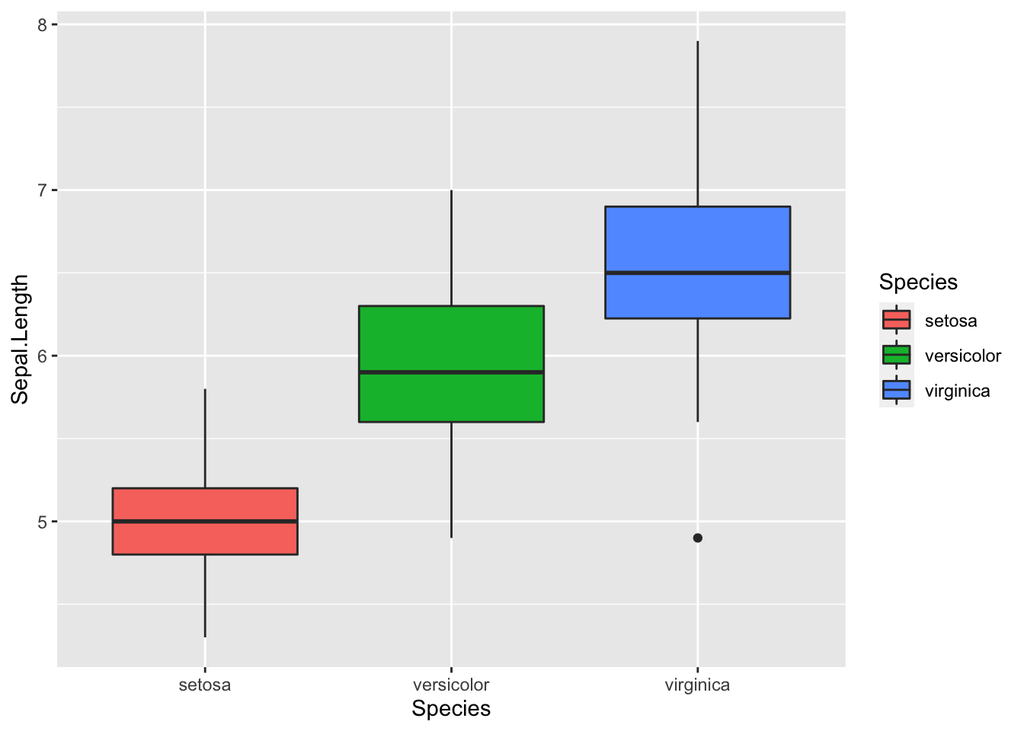

```r
# a boxplot of the sepal length of the three species
iris %>%
  ggplot2::ggplot(aes(x = Species, y = Sepal.Length, fill = Species)) +
  geom_boxplot()
```

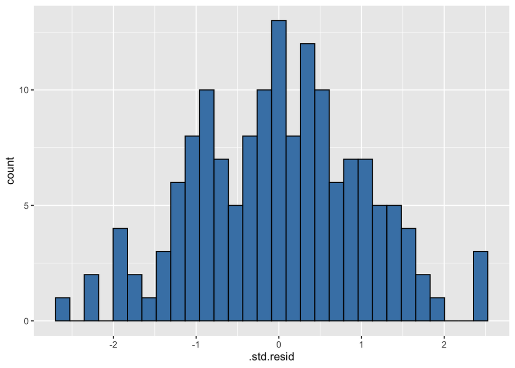

```r
# plotting the standardized residuals of the multiple regression analysis example model
broom::augment(res_lm3) %>% # results of the multiple regression
  ggplot(aes(x = .std.resid)) +
  geom_histogram(fill = "steelblue", color = "black")
## `stat_bin()` using `bins = 30`. Pick better value with `binwidth`.
```

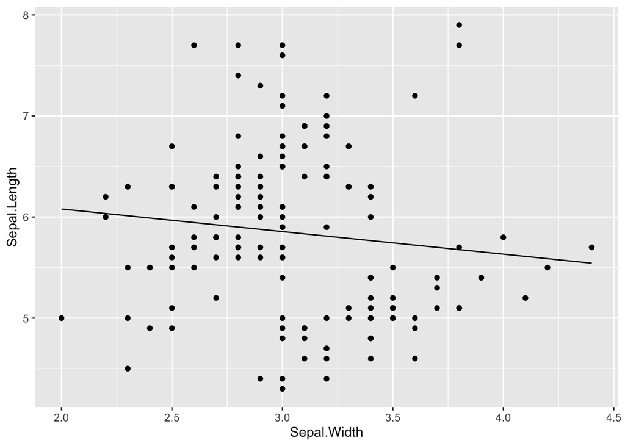

```r
# plotting the data and the fitted regression line of the simple regression
broom::augment(res_lm2) %>% # results of the simple regression
  ggplot(aes(x = Sepal.Width, y = Sepal.Length)) +
  geom_point() + # data points
  geom_line(aes(y = .fitted)) # regression line
```

## 3.2 Exercises

In 2011, an interesting [paper](https://journals.sagepub.com/doi/full/10.1177/0956797611417632) was published about how flexibility in data collection, analysis, and reporting can dramatically increase false-positive rates (Simmons, Nelson, & Simonsohn, 2011). They demonstrate how flexibility on these different aspects can result in statistically significant evidence for a false hypothesis. They conducted two experiments. In this assignment you will work with the data of the first study (the same data that was used for the fully working script example at the beginning of the Tidyverse chapter).

*Reference*: Simmons, J. P., Nelson, L. D., & Simonsohn, U. (2011). False-positive psychology: Undisclosed flexibility in data collection and analysis allows presenting anything as significant. *Psychological science, 22*, 1359-1366.

### Data

The data of this paper can be downloaded here: http://dx.doi.org/10.5281/zenodo.7664

Download the zip file, and in it you will find the data file called *Study 1 .txt*. Read this data into R. The easiest way to do so is by using the Import Dataset dropdown menu under the environment tab, and then choose the From Text (readr) option.

A text file called *Codebook.txt* provides a short description of each variable.

### Descriptive statistics

Carefully go over the information in the *The dplyr package* and *Descriptive statistics functions* subsections. Additionally, the fully working script at the beginning of the Tidyverse chapter might serve as a helpful example.

- Compute the minimum, maximum, mean, and standard deviation of the following variables at once: computer, dad, mom, and political.
- Compute the mean and standard deviation of age in years per condition, only for females.

### Regression analysis

Carefully review the *Statistical tests & Tidymodels* subsection before trying these exercises. Additionally, the example in the fully working script at the beginning of the Tidyverse chapter might be helpful.

Let’s try to predict students agreement with the statement “Computers are complicated machines” using their dad’s age, mom’s age, and their political orientation.

- Fit the corresponding linear regression model
- Extract the results. Get all relevant output such that you would be able to report the R squared of the model, and the regression coefficients (estimates) for all three independent variables and the corresponding p-values.

### Histogram

Create a histogram of the standardized residuals of your fitted regression model.

**Optional challenge** – Check the *ggplot2* [cheatsheet](https://rstudio.com/wp-content/uploads/2015/03/ggplot2-cheatsheet.pdf), and try to change the axis labels, to change the theme, and add a title.

### Solutions

> Learning R is a journey, not a destination

## 3.3 Break

[figure not shown]

xkcd.com

# 4 Wrap up

## 4.1 Clear your workspace

Marie Kondo will be proud of you.

```r
rm(list=ls())  # clear environment
cat("\014")  # clear console
dev.off(dev.list()["RStudioGD"])  # clear plots
```

## 4.2 Help (outside R)

*Take-away: (1) research your question (2) make it specific (3) most problems have been solved before: find and learn (4) if not: make sure others will learn from it.*

**Where and how to search**

- Use your favorite general purpose search engine or the R search engine [RSeek](https://rseek.org/)
- Search [Stack Overflow](https://stackoverflow.com/questions/tagged/r)
  - [tag]: [r]
  - -exclude
  - “exact phrase”
  - combined: [r] tidyverse “exact phrase” -exclude
- Search the [RStudio Community](https://community.rstudio.com/)

**Where to ask**

- Ask your fellow students on Piazza
- Ask the Rstudio Community
- Ask the world on [Stack Overflow](https://stackoverflow.com/questions/ask/advice?)

**How to ask**

- Tips from Stack Overflow: [1](https://stackoverflow.com/help/how-to-ask), [2](https://stackoverflow.com/questions/ask/advice?)
- Add a [reproducible example](https://stackoverflow.com/help/minimal-reproducible-example) with [reprex](https://reprex.tidyverse.org/)
- Show what you’ve done to solve it yourself

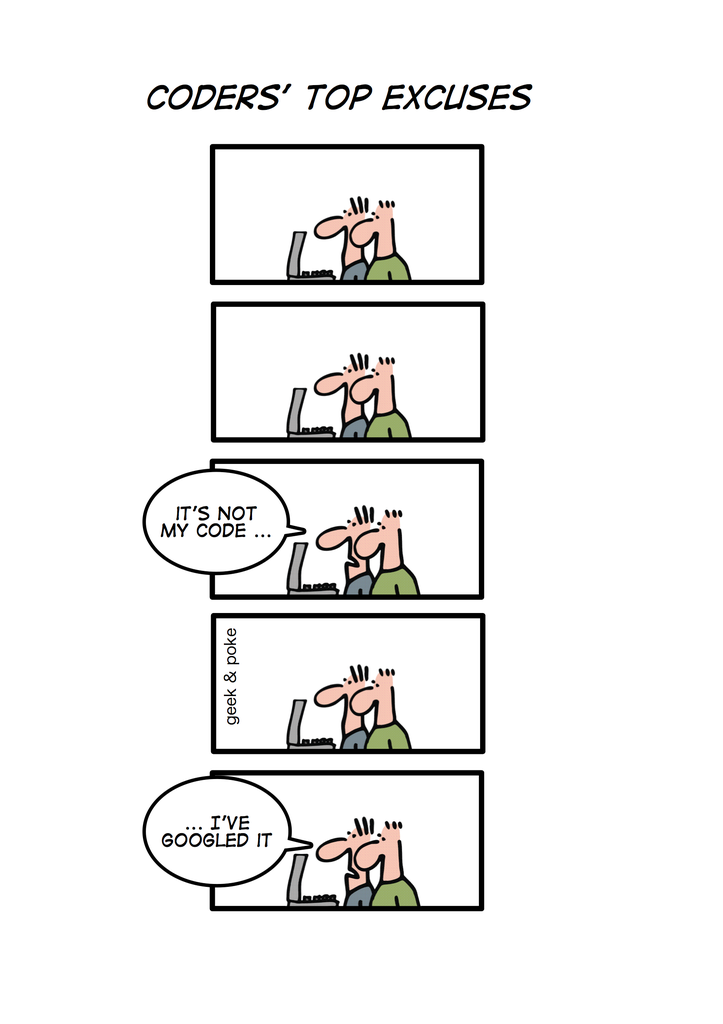

## 4.3 Take home assignments

### Explore your data

Grab some of your own data, tidy it, and load it into R. Start applying what you’ve learned so far!

**Readily available data**

Don’t have your own data? Or want practice data? Some R packages contain data that you can freely use. Unfortunately, many data does not come as a data frame or tibble, and is thus not suitable (below we give a short list of data that is).

- Run `data()` to see which data sets are available in the (loaded) packages.
- Run `data(package = "dplyr")` to look for data sets in the `dplyr` package (replace with any other package)
- Run `help("storms")` to get information on the `storms` data set (replace with any other data set)
- Run `data("storms")` to load the `storms` data set (replace with any other data set)

**Data frames and tibbles**

Data in packages that belong to the tidyverse (such as `dplyr` and `tidyr`), have a higher chance of being in the `tibble()` format that you are now familiar with. Here are some examples that you might find useful.

```r
help("iris")
help("mtcars")
help("storms")  # longitudinal data
```

**Data packages**

Some packages contain only data. There are many such data packages, but you won’t be able to find them easily. Follow [this link](https://rviews.rstudio.com/2017/11/01/r-data-packages/) to get an overview of some data packages from 2017.

## 4.4 What’s next?

**Bring me to the exit**

Okay, we failed. But you should nevertheless try the great projects below. They use R in the background, but have very friendly interfaces. They are like diet R; not as versatile as writing your own scripts, but easy to use, free and open source, and accompanied with great text books.

- Software: [JASP](https://jasp-stats.org/). Book: [Learning statistics with JASP](https://learnstatswithjasp.com/).
- Software: [jamovi](https://www.jamovi.org/). Book: [Learning statistics with jamovi](https://doi.org/10.24384/hgc3-7p15).

Also, our way of teaching might just not be your way of learning. You can find many other approaches online, for instance on DataCamp or Coursera.

**Let me practice, practice, practice, practice**

Great idea, time to conquer the learning curve! Here are some useful resources.

- Consult free resources
  - The book [R for Data Science](https://r4ds.had.co.nz/), by Hadley Wickham and Garrett Grolemund, is **probably the best place to start**
  - [More](https://www.tidyverse.org/learn/) resources for learning the tidyverse
  - Have a look at [RStudio Education](https://education.rstudio.com/learn/)
  - Download, print, and familiarize yourself with [RStudio’s cheat sheets](https://rstudio.com/resources/cheatsheets/). Pick the ones you need and put them in [clear plastic sleeves](https://www.hema.nl/vrije-tijd-kantoor/school-kantoor/mappen-ordners/snelhechters-showmappen/showalbum-a4-14822239.html). You’ll love to have them on your desk!
- Consult paid resources
  - If you like Andy Field’s books, you might like his [Discovering Statistics using R](https://www.discoveringstatistics.com/books/discovering-statistics-using-r/) book
  - If you’re coming from Stata, you might like the [R for Stata Users](https://link.springer.com/book/10.1007/978-1-4419-1318-0) book
  - If you’re coming from SAS or SPSS, you might like the [R for SAS and SPSS Users](https://link.springer.com/book/10.1007%2F978-0-387-09418-2) book
- Read the news
  - Follow [#rstats](https://twitter.com/search?q=%23rstats)
  - Read the [tidyverse blog](https://www.tidyverse.org/blog/)
  - Read [R blogs](https://www.r-bloggers.com/) from all around the world
- Get help
  - Don’t forget you can consult your fellow year group on Piazza

**Give me more**

Check out the syllabus to see the other masterclasses in this series. And check the [graphics](https://www.r-graph-gallery.com/) you can create with R and what you can do with [R Markdown](https://rmarkdown.rstudio.com/gallery.html), fancy right!

But. You’ll probably first want to practice with your newly obtained skills.